# Problem 1: Linear Regression

### Bivariate Analysis

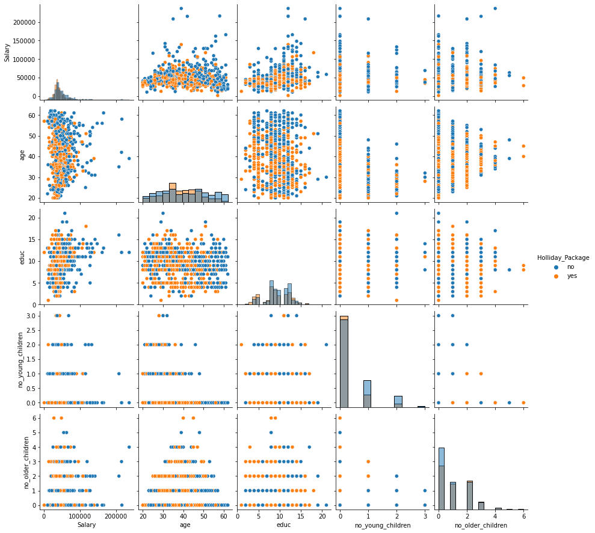

```python
sns.pairplot(dfh, diag_kind='hist', hue='Holliday_Package')
plt.show()
```

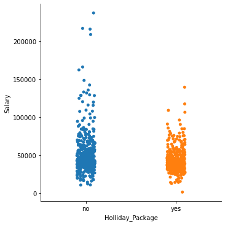

```python
sns.catplot(data = dfh, x='Holliday_Package',y='Salary')
```

### Multivariate Analysis

```python
dfh.corr()
```

|  | Salary | age | educ | no_young_children | no_older_children |
| --- | --- | --- | --- | --- | --- |
| Salary | 1.000000 | 0.071709 | 0.326540 | -0.029664 | 0.113772 |
| age | 0.071709 | 1.000000 | -0.149294 | -0.519093 | -0.116205 |
| educ | 0.326540 | -0.149294 | 1.000000 | 0.098350 | -0.036321 |
| no_young_children | -0.029664 | -0.519093 | 0.098350 | 1.000000 | -0.238428 |
| no_older_children | 0.113772 | -0.116205 | -0.036321 | -0.238428 | 1.000000 |

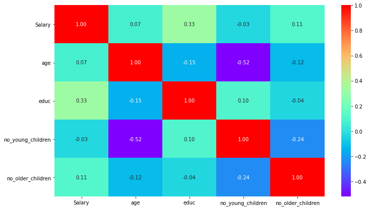

```python
plt.figure(figsize=(12,7))
sns.heatmap(dfh.corr(), annot=True, fmt='.2f', cmap= 'rainbow')
plt.show()
```

#### No multicolinearity in the data

## 2.2 Do not scale the data. Encode the data (having string values) for Modelling. Data Split: Split the data into train and test (70:30). Apply Logistic Regression and LDA (linear discriminant analysis).

### Outlier Checks

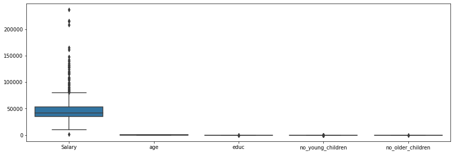

```python
#Check for presence of outliers
plt.figure(figsize=(15,5))
sns.boxplot(data=dfh)
plt.show()
```

#### Salary, educ, no_young_children and no_older_children have outliers. We need to treat outliers on the data.

```python
def remove_outlier(col):
    sorted(col)
    Q1,Q3=col.quantile([0.25,0.75])
    IQR=Q3-Q1
    lower_range= Q1-(1.5 * IQR)
    upper_range= Q3+(1.5 * IQR)
    return lower_range, upper_range
```

```python
lrSalary,urSalary=remove_outlier(dfh['Salary'])
dfh['Salary']=np.where(dfh['Salary']>urSalary,urSalary,dfh['Salary'])
dfh['Salary']=np.where(dfh['Salary']<lrSalary,lrSalary,dfh['Salary'])

lreduc,ureduc=remove_outlier(dfh['educ'])
dfh['educ']=np.where(dfh['educ']>ureduc,ureduc,dfh['educ'])
dfh['educ']=np.where(dfh['educ']<lreduc,lreduc,dfh['educ'])

lrno_young_children,urno_young_children=remove_outlier(dfh['no_young_children'])
dfh['no_young_children']=np.where(dfh['no_young_children']>urno_young_children,urno_young_children,dfh['no_young_children'])
dfh['no_young_children']=np.where(dfh['no_young_children']<lrno_young_children,lrno_young_children,dfh['no_young_children'])

lrno_older_children,urno_older_children=remove_outlier(dfh['no_older_children'])
dfh['no_older_children']=np.where(dfh['no_older_children']>urno_older_children,urno_older_children,dfh['no_older_children'])
dfh['no_older_children']=np.where(dfh['no_older_children']<lrno_older_children,lrno_older_children,dfh['no_older_children'])

df.shape
```

```
(26925, 10)
```

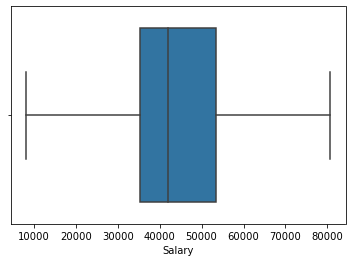

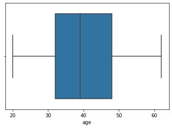

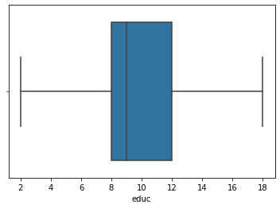

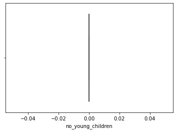

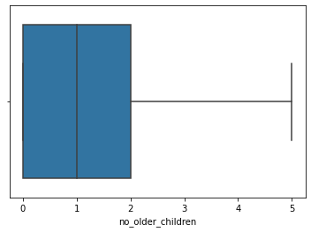

```python
cols = ['Salary', 'age', 'educ', 'no_young_children', 'no_older_children']

for i in cols:
    sns.boxplot(x=dfh[i])
    plt.show()
```

### Data encoding

#### Converting categorical to dummy variables in data

```python
data2 = pd.get_dummies(dfh, columns=['Holliday_Package','foreign'], drop_first = True)
```

```python
data2.head()
```

|  | Salary | age | educ | no_young_children | no_older_children | Holliday_Package_yes | foreign_yes |
| --- | --- | --- | --- | --- | --- | --- | --- |
| 0 | 48412.0 | 30 | 8.0 | 0.0 | 1.0 | 0 | 0 |
| 1 | 37207.0 | 45 | 8.0 | 0.0 | 1.0 | 1 | 0 |
| 2 | 58022.0 | 46 | 9.0 | 0.0 | 0.0 | 0 | 0 |
| 3 | 66503.0 | 31 | 11.0 | 0.0 | 0.0 | 0 | 0 |
| 4 | 66734.0 | 44 | 12.0 | 0.0 | 2.0 | 0 | 0 |

```python
data2.columns
```

```
Index(['Salary', 'age', 'educ', 'no_young_children', 'no_older_children',
       'Holliday_Package_yes', 'foreign_yes'],
      dtype='object')
```

### Train/ Test split

#### Extracting the target column into separate vectors for training set and test set

```python
x = data2.drop('Holliday_Package_yes', axis=1)
y = data2['Holliday_Package_yes']
```

#### Splitting data into training and test set

```python
x_train, x_test, y_train, y_test = train_test_split(x, y, test_size=0.30 , random_state=1)
```

#### Checking the dimensions of the training and test data

```python
print('x_train',x_train.shape)
print('x_test',x_test.shape)
print('y_train',y_train.shape)
print('y_test',y_test.shape)
```

```
x_train (610, 6)
x_test (262, 6)
y_train (610,)
y_test (262,)
```

### Logistic Regression Model

```python
# Fit the Logistic Regression model
grid={'penalty':['l2','none'],
      'solver':['sag','lbfgs','newton-cg'],
      'tol':[0.0001,0.00001]}
```

```python
model = LogisticRegression(max_iter=10000,verbose=True,n_jobs=2)
```

```python
grid_search = GridSearchCV(estimator = model, param_grid = grid, cv = 3,n_jobs=-1,scoring='f1')
```

```python
grid_search.fit(x_train, y_train)
```

```
[Parallel(n_jobs=2)]: Using backend LokyBackend with 2 concurrent workers.
[Parallel(n_jobs=2)]: Done   1 out of   1 | elapsed:    1.8s finished
```

```
GridSearchCV(cv=3,
             estimator=LogisticRegression(max_iter=10000, n_jobs=2,
                                          verbose=True),
             n_jobs=-1,
             param_grid={'penalty': ['l2', 'none'],
                         'solver': ['sag', 'lbfgs', 'newton-cg'],
                         'tol': [0.0001, 1e-05]},
             scoring='f1')
```

```python
print(grid_search.best_params_,'\n')
print(grid_search.best_estimator_)
```

```
{'penalty': 'none', 'solver': 'newton-cg', 'tol': 0.0001}

LogisticRegression(max_iter=10000, n_jobs=2, penalty='none', solver='newton-cg',
                   verbose=True)
```

```python
best_model = grid_search.best_estimator_
```

### Linear Discriminant Analysis (LDA)

```python
from sklearn.discriminant_analysis import LinearDiscriminantAnalysis
```

### Train/ Test split

#### Extracting the target column into separate vectors for training set and test set

```python
X = data2.drop('Holliday_Package_yes', axis=1)
Y = data2['Holliday_Package_yes']
```

#### Splitting data into training and test set

```python
X_train, X_test, Y_train, Y_test = train_test_split(X, Y, test_size=0.30 , random_state=1)
```

#### Checking the dimensions of the training and test data

```python
print('X_train',X_train.shape)
print('X_test',X_test.shape)
print('Y_train',Y_train.shape)
print('Y_test',Y_test.shape)
```

```
X_train (610, 6)
X_test (262, 6)
Y_train (610,)
Y_test (262,)
```

```python
# Build LDA Model
clf = LinearDiscriminantAnalysis()
modellda=clf.fit(X_train,Y_train)
modellda
```

```
LinearDiscriminantAnalysis()
```

### 2.3 Performance Metrics: Check the performance of Predictions on Train and Test sets using Accuracy, Confusion Matrix, Plot ROC curve and get ROC_AUC score for each model Final Model: Compare Both the models and write inference which model is best/optimized.

### Logistic Regression Model

#### Predicting on Training and Test dataset

```python
ytrain_predict = best_model.predict(x_train)
ytest_predict = best_model.predict(x_test)
```

#### Getting the Predicted Classes and Probs

```python
ytest_predict_prob=best_model.predict_proba(x_test)
pd.DataFrame(ytest_predict_prob).head()
```

|  | 0 | 1 |
| --- | --- | --- |
| 0 | 0.696807 | 0.303193 |
| 1 | 0.332213 | 0.667787 |
| 2 | 0.620128 | 0.379872 |
| 3 | 0.686886 | 0.313114 |
| 4 | 0.354964 | 0.645036 |

### Model Evaluation

```python
# Accuracy - Training Data
lr_train_acc = best_model.score(x_train, y_train)
lr_train_acc
```

```
0.6409836065573771
```

#### AUC and ROC for the training data

```
AUC: 0.667
```

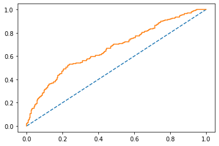

```python
# predict probabilities
probs = best_model.predict_proba(x_train)
# keep probabilities for the positive outcome only
probs = probs[:, 1]
# calculate AUC
lr_train_auc = roc_auc_score(y_train, probs)
print('AUC: %.3f' % lr_train_auc)
# calculate roc curve
train_fpr, train_tpr, train_thresholds = roc_curve(y_train, probs)
plt.plot([0, 1], [0, 1], linestyle='--')
# plot the roc curve for the model
plt.plot(train_fpr, train_tpr);
```

```python
# Accuracy - Test Data
lr_test_acc = best_model.score(x_test, y_test)
lr_test_acc
```

```
0.6297709923664122
```

#### AUC and ROC for the test data

```
AUC: 0.661
```

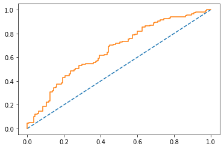

```python
# predict probabilities
probs = best_model.predict_proba(x_test)
# keep probabilities for the positive outcome only
probs = probs[:, 1]
# calculate AUC
lr_test_auc = roc_auc_score(y_test, probs)
print('AUC: %.3f' % lr_test_auc)
# calculate roc curve
test_fpr, test_tpr, test_thresholds = roc_curve(y_test, probs)
plt.plot([0, 1], [0, 1], linestyle='--')
# plot the roc curve for the model
plt.plot(test_fpr, test_tpr);
```

#### Confusion Matrix for the training data

```python
confusion_matrix(y_train, ytrain_predict)
```

```
array([[265,  61],
       [158, 126]], dtype=int64)
```

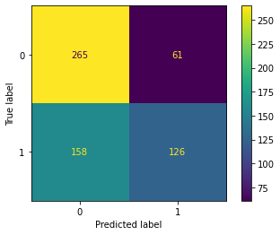

```python
plot_confusion_matrix(best_model,x_train,y_train);
```

```python
print(classification_report(y_train, ytrain_predict))
```

```
              precision    recall  f1-score   support

           0       0.63      0.81      0.71       326
           1       0.67      0.44      0.54       284

    accuracy                           0.64       610
   macro avg       0.65      0.63      0.62       610
weighted avg       0.65      0.64      0.63       610
```

```python
lr_metrics=classification_report(y_train, ytrain_predict,output_dict=True)
df5=pd.DataFrame(lr_metrics).transpose()
lr_train_f1=round(df5.loc["1"][2],2)
lr_train_recall=round(df5.loc["1"][1],2)
lr_train_precision=round(df5.loc["1"][0],2)
print ('lr_train_precision ',lr_train_precision)
print ('lr_train_recall ',lr_train_recall)
print ('lr_train_f1 ',lr_train_f1)
```

```
lr_train_precision  0.67
lr_train_recall  0.44
lr_train_f1  0.54
```

#### Confusion Matrix for test data

```python
confusion_matrix(y_test, ytest_predict)
```

```
array([[113,  32],
       [ 65,  52]], dtype=int64)
```

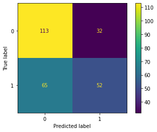

```python
plot_confusion_matrix(best_model,x_test,y_test);
```

```python
print(classification_report(y_test, ytest_predict))
```

```
              precision    recall  f1-score   support

           0       0.63      0.78      0.70       145
           1       0.62      0.44      0.52       117

    accuracy                           0.63       262
   macro avg       0.63      0.61      0.61       262
weighted avg       0.63      0.63      0.62       262
```

```python
lr_metrics=classification_report(y_test, ytest_predict,output_dict=True)
df5=pd.DataFrame(lr_metrics).transpose()
lr_test_f1=round(df5.loc["1"][2],2)
lr_test_recall=round(df5.loc["1"][1],2)
lr_test_precision=round(df5.loc["1"][0],2)
print ('lr_test_precision ',lr_test_precision)
print ('lr_test_recall ',lr_test_recall)
print ('lr_test_f1 ',lr_test_f1)
```

```
lr_test_precision  0.62
lr_test_recall  0.44
lr_test_f1  0.52
```

### Linear Discriminant Analysis (LDA)

#### Prediction

```python
# Training Data Class Prediction with a cut-off value of 0.5
pred_class_train = modellda.predict(X_train)

# Test Data Class Prediction with a cut-off value of 0.5
pred_class_test = modellda.predict(X_test)
```

#### Accuracy

```python
lda_train_acc = modellda.score(X_train,Y_train)
lda_train_acc
```

```
0.6426229508196721
```

```python
lda_test_acc = modellda.score(X_test,Y_test)
lda_test_acc
```

```
0.6297709923664122
```

#### Training Data and Test Data Confusion Matrix Comparison

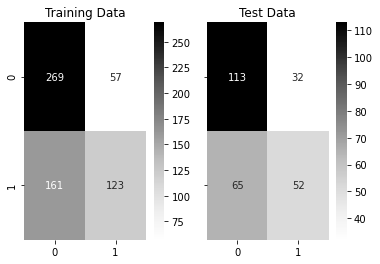

```python
f,a =  plt.subplots(1,2,sharex=True,sharey=True,squeeze=False)

#Plotting confusion matrix for the different models for the Training Data

plot_0 = sns.heatmap((metrics.confusion_matrix(Y_train,pred_class_train)),annot=True,fmt='.5g',cmap='Greys',ax=a[0][0]);
a[0][0].set_title('Training Data')

plot_1 = sns.heatmap((metrics.confusion_matrix(Y_test,pred_class_test)),annot=True,fmt='.5g',cmap='Greys',ax=a[0][1]);
a[0][1].set_title('Test Data');
```

#### Training Data and Test Data Classification Report Comparison

```python
print('Classification Report of the training data:\n\n',metrics.classification_report(Y_train,pred_class_train),'\n')
print('Classification Report of the test data:\n\n',metrics.classification_report(Y_test,pred_class_test),'\n')
```

```
Classification Report of the training data:

               precision    recall  f1-score   support

           0       0.63      0.83      0.71       326
           1       0.68      0.43      0.53       284

    accuracy                           0.64       610
   macro avg       0.65      0.63      0.62       610
weighted avg       0.65      0.64      0.63       610


Classification Report of the test data:

               precision    recall  f1-score   support

           0       0.63      0.78      0.70       145
           1       0.62      0.44      0.52       117

    accuracy                           0.63       262
   macro avg       0.63      0.61      0.61       262
weighted avg       0.63      0.63      0.62       262
```

#### Probability prediction for the training and test data

```python
# Training Data Probability Prediction
pred_prob_train = modellda.predict_proba(X_train)

# Test Data Probability Prediction
pred_prob_test = modellda.predict_proba(X_test)
```

```python
pred_prob_train[:,1]
```

[output not shown]

[output cut: 67 more lines]

[output not shown]

```
AUC for the Training Data: 0.667
AUC for the Test Data: 0.662
```

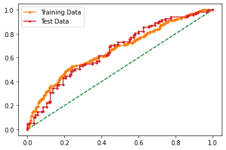

```python
# AUC and ROC for the training data

# calculate AUC
lda_train_auc = metrics.roc_auc_score(Y_train,pred_prob_train[:,1])
print('AUC for the Training Data: %.3f' % lda_train_auc)

#  calculate roc curve
fpr, tpr, thresholds = metrics.roc_curve(Y_train,pred_prob_train[:,1])
plt.plot([0, 1], [0, 1], linestyle='--')
# plot the roc curve for the model
plt.plot(fpr, tpr, marker='.',label = 'Training Data')


# AUC and ROC for the test data

# calculate AUC
lda_test_auc = metrics.roc_auc_score(Y_test,pred_prob_test[:,1])
print('AUC for the Test Data: %.3f' % lda_test_auc)

#  calculate roc curve
fpr, tpr, thresholds = metrics.roc_curve(Y_test,pred_prob_test[:,1])
plt.plot([0, 1], [0, 1], linestyle='--')
# plot the roc curve for the model
plt.plot(fpr, tpr, marker='.',label='Test Data')
# show the plot
plt.legend(loc='best')
plt.show()
```

#### Change the cut-off values to get maximum accuracy

```
0.1

Accuracy Score 0.4656
F1 Score 0.6353

Confusion Matrix
```

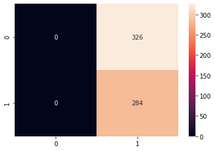

```
0.2

Accuracy Score 0.4721
F1 Score 0.6382

Confusion Matrix
```

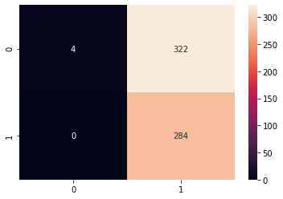

```
0.3

Accuracy Score 0.523
F1 Score 0.6447

Confusion Matrix
```

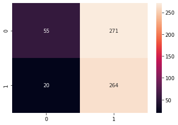

```
0.4

Accuracy Score 0.5967
F1 Score 0.618

Confusion Matrix
```

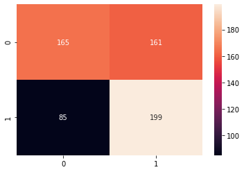

```
0.5

Accuracy Score 0.6426
F1 Score 0.5302

Confusion Matrix
```

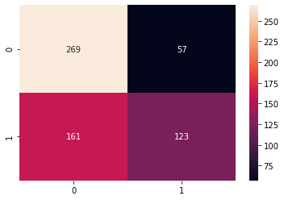

```
0.6

Accuracy Score 0.6328
F1 Score 0.4717

Confusion Matrix
```

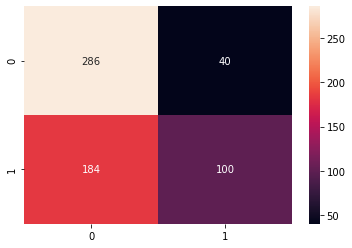

```
0.7

Accuracy Score 0.6082
F1 Score 0.3558

Confusion Matrix
```

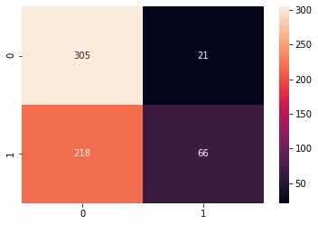

```
0.8

Accuracy Score 0.5377
F1 Score 0.014

Confusion Matrix
```

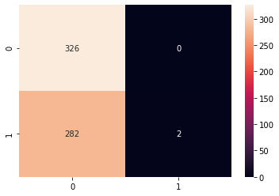

```
0.9

Accuracy Score 0.5344
F1 Score 0.0

Confusion Matrix
```

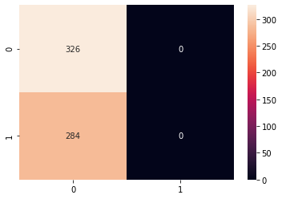

```python
for j in np.arange(0.1,1,0.1):
    custom_prob = j #defining the cut-off value of our choice
    custom_cutoff_data=[]#defining an empty list
    for i in range(0,len(Y_train)):#defining a loop for the length of the test data
        if np.array(pred_prob_train[:,1])[i] > custom_prob:#issuing a condition for our probability values to be
            #greater than the custom cutoff value
            a=1 #if the probability values are greater than the custom cutoff then the value should be 1
        else:
            a=0 #if the probability values are less than the custom cutoff then the value should be 0
        custom_cutoff_data.append(a)#adding either 1 or 0 based on the condition to the end of the list defined by us
    print(round(j,3),'\n')
    print('Accuracy Score',round(metrics.accuracy_score(Y_train,custom_cutoff_data),4))
    print('F1 Score',round(metrics.f1_score(Y_train,custom_cutoff_data),4),'\n')
    plt.figure(figsize=(6,4))
    print('Confusion Matrix')
    sns.heatmap(metrics.confusion_matrix(Y_train,custom_cutoff_data),annot=True,fmt='.4g'),'\n\n'
    plt.show();
```

#### For all other cut off values, accuracy is low compared with cutoff value of 0.5.

```python
lda_metrics=classification_report(Y_train, pred_class_train,output_dict=True)
df4=pd.DataFrame(lda_metrics).transpose()
lda_train_f1=round(df4.loc["1"][2],2)
lda_train_recall=round(df4.loc["1"][1],2)
lda_train_precision=round(df4.loc["1"][0],2)
print ('lda_train_precision ',lda_train_precision)
print ('lda_train_recall ',lda_train_recall)
print ('lda_train_f1 ',lda_train_f1)
```

```
lda_train_precision  0.68
lda_train_recall  0.43
lda_train_f1  0.53
```

```python
lda_metrics=classification_report(Y_test, pred_class_test,output_dict=True)
df4=pd.DataFrame(lda_metrics).transpose()
lda_test_f1=round(df4.loc["1"][2],2)
lda_test_recall=round(df4.loc["1"][1],2)
lda_test_precision=round(df4.loc["1"][0],2)
print ('lda_test_precision ',lda_test_precision)
print ('lda_test_recall ',lda_test_recall)
print ('lda_test_f1 ',lda_test_f1)
```

```
lda_test_precision  0.62
lda_test_recall  0.44
lda_test_f1  0.52
```

```python
index=['Accuracy', 'AUC', 'Recall','Precision','F1 Score']
dataf = pd.DataFrame({'LR Train':[lr_train_acc,lr_train_auc,lr_train_recall,lr_train_precision,lr_train_f1],
        'LR Test':[lr_test_acc,lr_test_auc,lr_test_recall,lr_test_precision,lr_test_f1],
       'LDA Train':[lda_train_acc,lda_train_auc,lda_train_recall,lda_train_precision,lda_train_f1],
        'LDA Test':[lda_test_acc,lda_test_auc,lda_test_recall,lda_test_precision,lda_test_f1],},index=index)
round(dataf,2)
```

|  | LR Train | LR Test | LDA Train | LDA Test |
| --- | --- | --- | --- | --- |
| Accuracy | 0.64 | 0.63 | 0.64 | 0.63 |
| AUC | 0.67 | 0.66 | 0.67 | 0.66 |
| Recall | 0.44 | 0.44 | 0.43 | 0.44 |
| Precision | 0.67 | 0.62 | 0.68 | 0.62 |
| F1 Score | 0.54 | 0.52 | 0.53 | 0.52 |

#### While compare with both models, we can see that both give same results. But LDA works better for target variable is categorical.

### 2.4 Inference: Basis on these predictions, what are the insights and recommendations.

Please explain and summarise the various steps performed in this project. There should be proper business interpretation and actionable insights present.

We need to predict that whether an employee would opt for a holiday package or not, for this I have done predictions using both logistic regression and linear discriminant analysis. As per the prediction both results are same.

The important factors for the predictions are salary, age and educ.